# Cal Criminals Final Project Report

Pranava Sai Maganti, Umesh Sai Teja Poola, Meghasyam Peddireddy

2024-12-09

```r
# Load required libraries
library(tidyverse)
library(readxl)
library(DT)
library(lubridate)
library(scales)
library(knitr)
library(kableExtra)
```

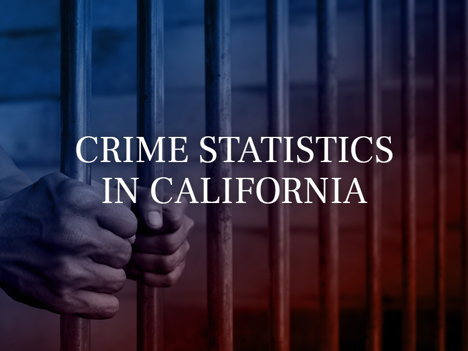

As planned in the Project Idea & Proposal, the following team members will be performing the following tasks for the final project.

| Team Member | Role |
| --- | --- |
| Meghasyam Peddireddy | Data Cleaning, Preprocessing |
| Umesh Sai Teja Poola | Exploratory Data Analysis, Modeling |
| Pranava Sai Maganti | Visualization, Interpretation |

## Data Cleaning and Preprocessing

### 1. Loading and Initial Data Inspection

```r
# Read the data
crimes_data <- read_excel("crimes-ca.xlsx", sheet = "ViolentCrime")
# Display the first few rows and basic information about the dataset
head(crimes_data) %>%
  kable() %>%
  kable_styling(bootstrap_options = c("striped", "hover"), full_width = FALSE)
```

| ind_id | ind_definition | reportyear | race_eth_code | race_eth_name | geotype | geotypevalue | geoname | county_fips | county_name | region_code | region_name | strata_name_code | strata_name | strata_level_name_code | strata_level_name | numerator | denominator | rate | ll_95ci | ul_95ci | se | rse | ca_decile | ca_rr | dof_population | version |
| --- | --- | --- | --- | --- | --- | --- | --- | --- | --- | --- | --- | --- | --- | --- | --- | --- | --- | --- | --- | --- | --- | --- | --- | --- | --- | --- |
| 752 | Number of Violent Crimes per 1,000 Population | 2000 | 9 | Total | CA | 06 | California | NA | NA | NA | NA | 1 | Type of violent crime | 1 | Aggravated assault | 138325 | 33847694 | NA | NA | NA | NA | NA | NA | NA | 33873086 | 2015-10-21 11:57:16 |
| 752 | Number of Violent Crimes per 1,000 Population | 2000 | 9 | Total | CA | 06 | California | NA | NA | NA | NA | 1 | Type of violent crime | 2 | Forcible rape | 9784 | 33847694 | NA | NA | NA | NA | NA | NA | NA | 33873086 | 2015-10-21 11:57:16 |
| 752 | Number of Violent Crimes per 1,000 Population | 2000 | 9 | Total | CA | 06 | California | NA | NA | NA | NA | 1 | Type of violent crime | 3 | Murder and non-negligent manslaughter | 2079 | 33847694 | NA | NA | NA | NA | NA | NA | NA | 33873086 | 2015-10-21 11:57:16 |
| 752 | Number of Violent Crimes per 1,000 Population | 2000 | 9 | Total | CA | 06 | California | NA | NA | NA | NA | 1 | Type of violent crime | 4 | Robbery | 60237 | 33847694 | NA | NA | NA | NA | NA | NA | NA | 33873086 | 2015-10-21 11:57:16 |
| 752 | Number of Violent Crimes per 1,000 Population | 2000 | 9 | Total | CA | 06 | California | NA | NA | NA | NA | 1 | Type of violent crime | 5 | Violent crime total | 210448 | 33847694 | 6.217499 | 6.190935 | 6.244063 | 0.0135532 | 0.2179855 | NA | 1 | 33873086 | 2015-10-21 11:57:16 |
| 752 | Number of Violent Crimes per 1,000 Population | 2000 | 9 | Total | CO | 06001 | Alameda | 06001 | Alameda | 01 | Bay Area | 1 | Type of violent crime | 1 | Aggravated assault | 5457 | 1443741 | NA | NA | NA | NA | NA | NA | NA | 1443939 | 2015-10-21 11:57:16 |

```r
# Display structure of the data
str(crimes_data)
```

```
## tibble [49,227 × 27] (S3: tbl_df/tbl/data.frame)
##  $ ind_id                : num [1:49227] 752 752 752 752 752 752 752 752 752 752 ...
##  $ ind_definition        : chr [1:49227] "Number of Violent Crimes per 1,000 Population" "Number of Violent Crimes per 1,000 Population" "Number of Violent Crimes per 1,000 Population" "Number of Violent Crimes per 1,000 Population" ...
##  $ reportyear            : chr [1:49227] "2000" "2000" "2000" "2000" ...
##  $ race_eth_code         : num [1:49227] 9 9 9 9 9 9 9 9 9 9 ...
##  $ race_eth_name         : chr [1:49227] "Total" "Total" "Total" "Total" ...
##  $ geotype               : chr [1:49227] "CA" "CA" "CA" "CA" ...
##  $ geotypevalue          : chr [1:49227] "06" "06" "06" "06" ...
##  $ geoname               : chr [1:49227] "California" "California" "California" "California" ...
##  $ county_fips           : chr [1:49227] NA NA NA NA ...
##  $ county_name           : chr [1:49227] NA NA NA NA ...
##  $ region_code           : chr [1:49227] NA NA NA NA ...
##  $ region_name           : chr [1:49227] NA NA NA NA ...
##  $ strata_name_code      : num [1:49227] 1 1 1 1 1 1 1 1 1 1 ...
##  $ strata_name           : chr [1:49227] "Type of violent crime" "Type of violent crime" "Type of violent crime" "Type of violent crime" ...
##  $ strata_level_name_code: num [1:49227] 1 2 3 4 5 1 2 3 4 5 ...
##  $ strata_level_name     : chr [1:49227] "Aggravated assault" "Forcible rape" "Murder and non-negligent manslaughter" "Robbery" ...
##  $ numerator             : num [1:49227] 138325 9784 2079 60237 210448 ...
##  $ denominator           : num [1:49227] 33847694 33847694 33847694 33847694 33847694 ...
##  $ rate                  : num [1:49227] NA NA NA NA 6.22 ...
##  $ ll_95ci               : num [1:49227] NA NA NA NA 6.19 ...
##  $ ul_95ci               : num [1:49227] NA NA NA NA 6.24 ...
##  $ se                    : num [1:49227] NA NA NA NA 0.0136 ...
##  $ rse                   : num [1:49227] NA NA NA NA 0.218 ...
##  $ ca_decile             : num [1:49227] NA NA NA NA NA NA NA NA NA NA ...
##  $ ca_rr                 : num [1:49227] NA NA NA NA 1 ...
##  $ dof_population        : num [1:49227] 33873086 33873086 33873086 33873086 33873086 ...
##  $ version               : POSIXct[1:49227], format: "2015-10-21 11:57:16" "2015-10-21 11:57:16" ...
```

### 2. Data Quality Assessment

```r
# Check for missing values
missing_values <- colSums(is.na(crimes_data))
missing_values_df <- data.frame(
  Column = names(missing_values),
  Missing_Values = missing_values
)

# Display missing values
missing_values_df %>%
  kable(caption = "Missing Values by Column") %>%
  kable_styling(bootstrap_options = c("striped", "hover"), full_width = FALSE)
```

Missing Values by Column

|  | Column | Missing_Values |
| --- | --- | --- |
| ind_id | ind_id | 1 |
| ind_definition | ind_definition | 1 |
| reportyear | reportyear | 1 |
| race_eth_code | race_eth_code | 1 |
| race_eth_name | race_eth_name | 1 |
| geotype | geotype | 1 |
| geotypevalue | geotypevalue | 1 |
| geoname | geoname | 1 |
| county_fips | county_fips | 1051 |
| county_name | county_name | 1051 |
| region_code | region_code | 71 |
| region_name | region_name | 71 |
| strata_name_code | strata_name_code | 1 |
| strata_name | strata_name | 1 |
| strata_level_name_code | strata_level_name_code | 1 |
| strata_level_name | strata_level_name | 1 |
| numerator | numerator | 16934 |
| denominator | denominator | 12137 |
| rate | rate | 41904 |
| ll_95ci | ll_95ci | 41904 |
| ul_95ci | ul_95ci | 41904 |
| se | se | 41904 |
| rse | rse | 41904 |
| ca_decile | ca_decile | 42926 |
| ca_rr | ca_rr | 41904 |
| dof_population | dof_population | 10567 |
| version | version | 1 |

```r
# Check for duplicate rows
duplicate_count <- sum(duplicated(crimes_data))
cat("Number of duplicate rows:", duplicate_count, "\n")
```

```
## Number of duplicate rows: 0
```

### 3. Data Cleaning

```r
# Clean the data step by step

# 1. Convert the data to a data frame
cleaned_crimes <- as.data.frame(crimes_data)

# 2. Inspect column names for debugging
colnames(cleaned_crimes)
```

```
##  [1] "ind_id"                 "ind_definition"         "reportyear"
##  [4] "race_eth_code"          "race_eth_name"          "geotype"
##  [7] "geotypevalue"           "geoname"                "county_fips"
## [10] "county_name"            "region_code"            "region_name"
## [13] "strata_name_code"       "strata_name"            "strata_level_name_code"
## [16] "strata_level_name"      "numerator"              "denominator"
## [19] "rate"                   "ll_95ci"                "ul_95ci"
## [22] "se"                     "rse"                    "ca_decile"
## [25] "ca_rr"                  "dof_population"         "version"
```

```r
# 3. Handle missing values and duplicates
cleaned_crimes <- cleaned_crimes %>%
  drop_na() %>%     # Remove rows with missing values
  distinct()        # Remove duplicate rows

# 4. Use 'reportyear' instead of 'year' for the year information
# Create crime rate and ensure 'reportyear' is numeric
cleaned_crimes <- cleaned_crimes %>%
  mutate(
    crime_rate = (numerator / denominator) * 100000,
    reportyear = as.integer(reportyear) # Convert reportyear to integer
  )

# 5. Rename columns for clarity
cleaned_crimes <- cleaned_crimes %>%
  rename(
    year = reportyear,        # Rename reportyear to year for consistency
    crime_count = numerator,
    population = denominator,
    crime_type = strata_level_name
  )

# 6. Select and organize final columns
cleaned_crimes <- cleaned_crimes %>%
  select(
    year,
    region_name,
    county_name,
    crime_type,
    crime_count,
    population,
    crime_rate
  )

nrow(cleaned_crimes)
```

```
## [1] 6251
```

```r
ncol(cleaned_crimes)
```

```
## [1] 7
```

```r
# Display summary of the cleaned data
summary(cleaned_crimes) %>%
  kable() %>%
  kable_styling(bootstrap_options = c("striped", "hover"), full_width = FALSE)
```

|  | year | region_name | county_name | crime_type | crime_count | population | crime_rate |
| --- | --- | --- | --- | --- | --- | --- | --- |
|  | Min. :2000 | Length:6251 | Length:6251 | Length:6251 | Min. : 1.0 | Min. : 90 | Min. : 2.47 |
|  | 1st Qu.:2003 | Class :character | Class :character | Class :character | 1st Qu.: 33.0 | 1st Qu.: 12070 | 1st Qu.: 188.00 |
|  | Median :2007 | Mode :character | Mode :character | Mode :character | Median : 93.0 | Median : 30785 | Median : 338.90 |
|  | Mean :2007 | NA | NA | NA | Mean : 348.4 | Mean : 66287 | Mean : 565.25 |
|  | 3rd Qu.:2010 | NA | NA | NA | 3rd Qu.: 247.0 | 3rd Qu.: 66788 | 3rd Qu.: 549.32 |
|  | Max. :2013 | NA | NA | NA | Max. :52243.0 | Max. :3879455 | Max. :79569.89 |

### 4. Data Transformation and Feature Engineering

```r
# Create aggregated datasets for different analyses
yearly_totals <- cleaned_crimes %>%
  group_by(year) %>%
  summarise(
    total_crimes = sum(crime_count),
    total_population = sum(population),
    avg_crime_rate = mean(crime_rate)
  )

regional_totals <- cleaned_crimes %>%
  group_by(region_name) %>%
  summarise(
    total_crimes = sum(crime_count),
    avg_population = mean(population),
    avg_crime_rate = mean(crime_rate)
  ) %>%
  arrange(desc(total_crimes))

crime_type_totals <- cleaned_crimes %>%
  group_by(crime_type) %>%
  summarise(
    total_incidents = sum(crime_count),
    avg_rate = mean(crime_rate)
  ) %>%
  arrange(desc(total_incidents))

# Display summaries
kable(head(yearly_totals), caption = "Yearly Crime Totals") %>%
  kable_styling(bootstrap_options = c("striped", "hover"), full_width = FALSE)
```

Yearly Crime Totals

| year | total_crimes | total_population | avg_crime_rate |
| --- | --- | --- | --- |
| 2000 | 177434 | 27236957 | 669.4526 |
| 2001 | 181510 | 27764031 | 675.2150 |
| 2002 | 177076 | 28357569 | 637.6902 |
| 2003 | 173584 | 28682051 | 613.1552 |
| 2004 | 166633 | 28989497 | 597.3868 |
| 2005 | 158886 | 29177188 | 568.6286 |

```r
kable(head(regional_totals), caption = "Regional Crime Totals") %>%
  kable_styling(bootstrap_options = c("striped", "hover"), full_width = FALSE)
```

Regional Crime Totals

| region_name | total_crimes | avg_population | avg_crime_rate |
| --- | --- | --- | --- |
| Southern California | 1153959 | 84719.26 | 771.1938 |
| Bay Area | 433714 | 66816.13 | 324.3930 |
| San Joaquin Valley | 237170 | 47822.83 | 504.2475 |
| San Diego | 161056 | 140728.50 | 405.2598 |
| Sacramento Area | 91545 | 63583.85 | 435.6633 |
| Monterey Bay | 39993 | 28427.50 | 526.8211 |

```r
kable(head(crime_type_totals), caption = "Crime Type Totals") %>%
  kable_styling(bootstrap_options = c("striped", "hover"), full_width = FALSE)
```

Crime Type Totals

| crime_type | total_incidents | avg_rate |
| --- | --- | --- |
| Violent crime total | 2178185 | 565.2482 |

### 5. Data Quality Verification

```r
# Verify data quality after cleaning
verification_summary <- cleaned_crimes %>%
  summarise(
    row_count = n(),
    distinct_years = n_distinct(year),
    distinct_regions = n_distinct(region_name),
    distinct_counties = n_distinct(county_name),
    distinct_crime_types = n_distinct(crime_type),
    min_year = min(year),
    max_year = max(year),
    min_crime_rate = min(crime_rate),
    max_crime_rate = max(crime_rate)
  )

# Display verification summary
kable(verification_summary, caption = "Data Quality Verification Summary") %>%
  kable_styling(bootstrap_options = c("striped", "hover"), full_width = FALSE)
```

Data Quality Verification Summary

| row_count | distinct_years | distinct_regions | distinct_counties | distinct_crime_types | min_year | max_year | min_crime_rate | max_crime_rate |
| --- | --- | --- | --- | --- | --- | --- | --- | --- |
| 6251 | 14 | 14 | 53 | 1 | 2000 | 2013 | 2.47387 | 79569.89 |

### 6. Save Cleaned Data

```r
# Save the cleaned dataset for further analysis
write.csv(cleaned_crimes, "cleaned_crimes_data.csv", row.names = FALSE)

# Save the aggregated datasets
write.csv(yearly_totals, "yearly_totals.csv", row.names = FALSE)
write.csv(regional_totals, "regional_totals.csv", row.names = FALSE)
write.csv(crime_type_totals, "crime_type_totals.csv", row.names = FALSE)

cat("All cleaned datasets have been saved successfully!\n")
```

```
## All cleaned datasets have been saved successfully!
```

## Data Cleaning Summary

The data cleaning and preprocessing phase has been completed successfully. Here’s a summary of what was accomplished:

1. **Data Loading and Initial Inspection**
   - Loaded the raw data from crimes-ca.xlsx
   - Performed initial inspection of data structure and content
2. **Quality Assessment**
   - Identified missing values across all columns
   - Checked for duplicate entries
   - Examined data types and structure
3. **Data Cleaning**
   - Removed missing values and duplicates
   - Standardized column names
   - Calculated crime rates per 100,000 population
   - Selected relevant columns for analysis
4. **Data Transformation**
   - Created yearly summaries
   - Generated regional statistics
   - Compiled crime type aggregations
5. **Quality Verification**
   - Verified the completeness of the cleaned dataset
   - Confirmed data ranges and distributions
   - Validated calculated fields
6. **Data Export**
   - Saved cleaned and transformed datasets for further analysis
   - Created separate files for different analytical perspectives

The cleaned data is now ready for exploratory data analysis and modeling.

## Exploratory Data Analysis (EDA)

### 1. Descriptive Statistics

```r
# Descriptive statistics for crime rates
crime_summary <- cleaned_crimes %>%
  summarise(
    avg_crime_rate = mean(crime_rate),
    median_crime_rate = median(crime_rate),
    sd_crime_rate = sd(crime_rate),
    min_crime_rate = min(crime_rate),
    max_crime_rate = max(crime_rate)
  )

# Save descriptive statistics to a CSV file
write.csv(crime_summary, "crime_summary.csv", row.names = FALSE)

# Display crime summary statistics
kable(crime_summary, caption = "Crime Rate Summary Statistics") %>%
  kable_styling(bootstrap_options = c("striped", "hover"), full_width = FALSE)
```

Crime Rate Summary Statistics

| avg_crime_rate | median_crime_rate | sd_crime_rate | min_crime_rate | max_crime_rate |
| --- | --- | --- | --- | --- |
| 565.2482 | 338.9024 | 2752.21 | 2.47387 | 79569.89 |

### 2. Time Series Analysis

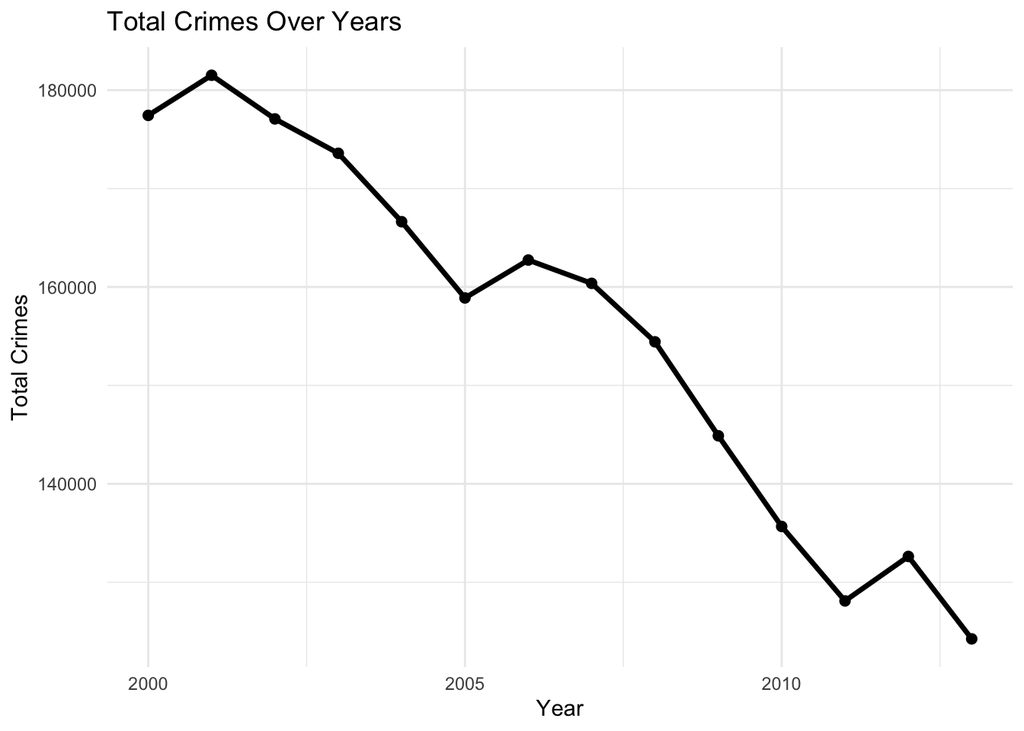

```r
# Aggregate yearly crime data
yearly_crime_data <- cleaned_crimes %>%
  group_by(year) %>%
  summarise(total_crimes = sum(crime_count))

# Save yearly crime data to a CSV file
write.csv(yearly_crime_data, "yearly_crime_data.csv", row.names = FALSE)

# Plot crime trends over the years
crime_trend_plot <- yearly_crime_data %>%
  ggplot(aes(x = year, y = total_crimes)) +
  geom_line(size = 1.2) +
  geom_point(size = 2) +
  labs(
    title = "Total Crimes Over Years",
    x = "Year",
    y = "Total Crimes"
  ) +
  theme_minimal()
crime_trend_plot
```

### 3. Regional Analysis

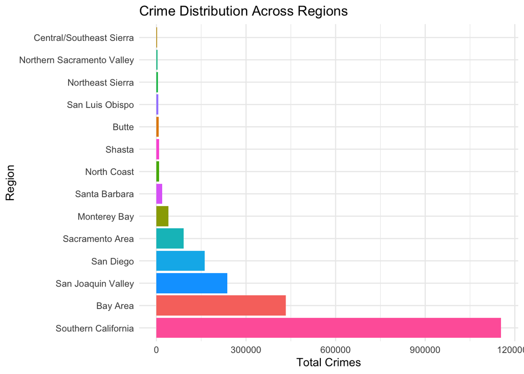

```r
# Aggregate regional crime data
regional_crime_data <- cleaned_crimes %>%
  group_by(region_name) %>%
  summarise(total_crimes = sum(crime_count))

# Save regional crime data to a CSV file
write.csv(regional_crime_data, "regional_crime_data.csv", row.names = FALSE)

# Crime distribution across regions
regional_crime_plot <- regional_crime_data %>%
  ggplot(aes(x = reorder(region_name, -total_crimes), y = total_crimes, fill = region_name)) +
  geom_bar(stat = "identity") +
  labs(
    title = "Crime Distribution Across Regions",
    x = "Region",
    y = "Total Crimes"
  ) +
  theme_minimal() +
  theme(legend.position = "none") +
  coord_flip()

regional_crime_plot
```

### 4. Trends Over Time

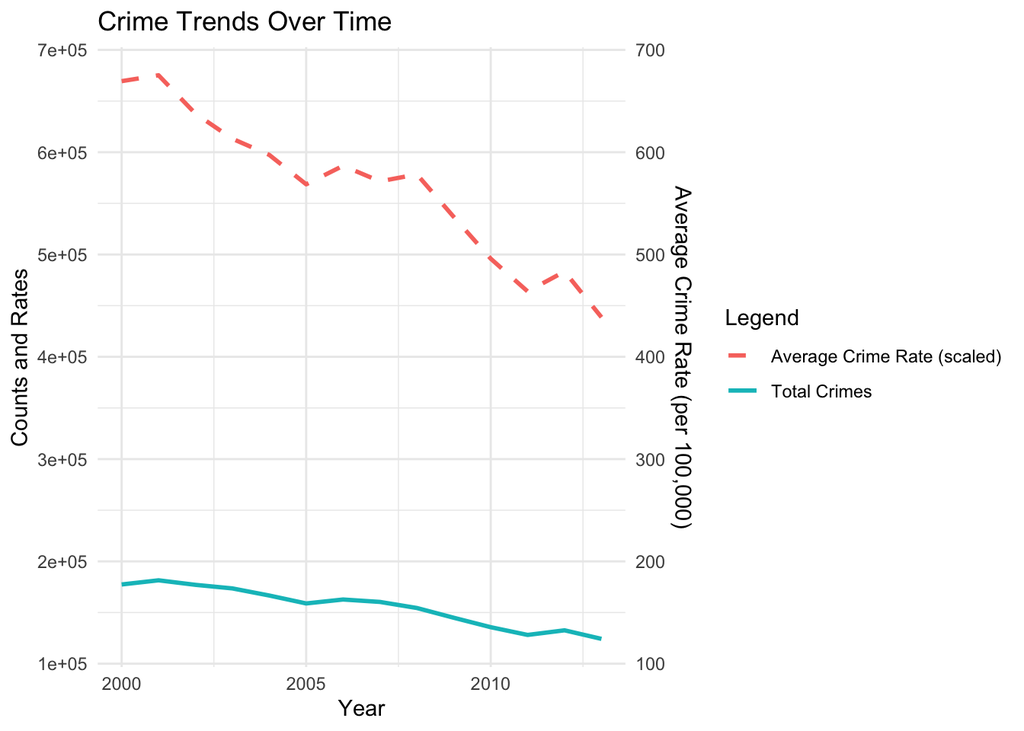

```r
# Analyze crime trends over time
ggplot(yearly_totals, aes(x = year)) +
  geom_line(aes(y = total_crimes, color = "Total Crimes"), size = 1) +
  geom_line(aes(y = avg_crime_rate * 1000, color = "Average Crime Rate (scaled)"), size = 1, linetype = "dashed") +
  scale_y_continuous(
    name = "Counts and Rates",
    sec.axis = sec_axis(~ ./1000, name = "Average Crime Rate (per 100,000)")
  ) +
  labs(
    title = "Crime Trends Over Time",
    x = "Year",
    y = "Total Crimes",
    color = "Legend"
  ) +
  theme_minimal()
```

### 5. Plot crime type distribution

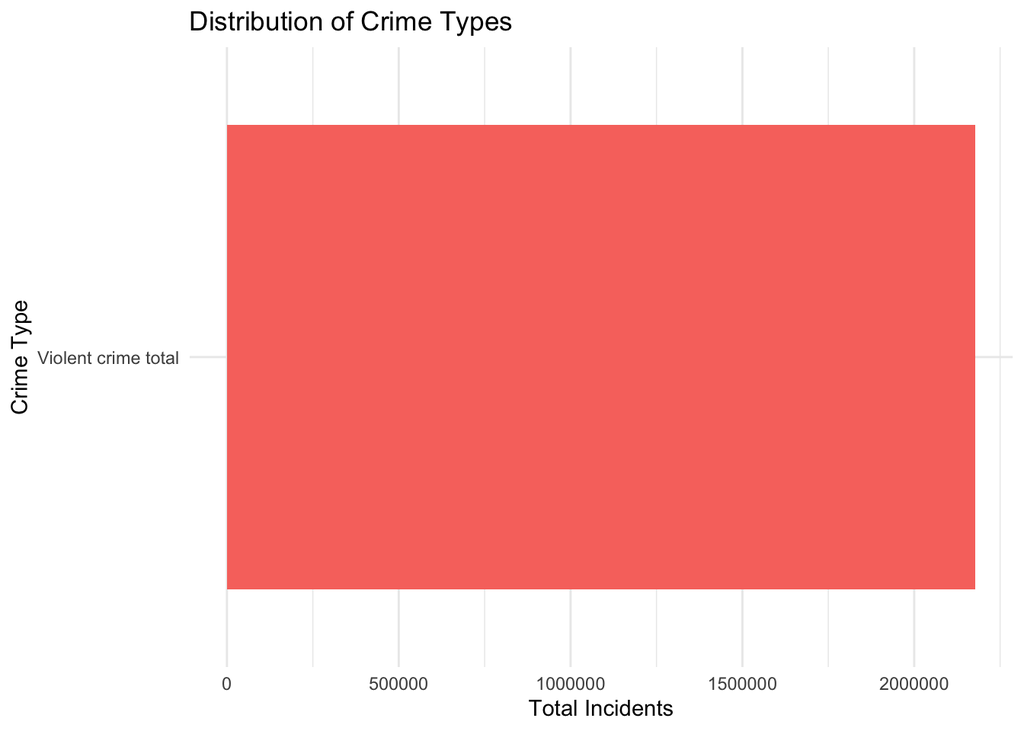

```r
ggplot(crime_type_totals, aes(x = reorder(crime_type, -total_incidents), y = total_incidents, fill = crime_type)) +
  geom_bar(stat = "identity") +
  labs(
    title = "Distribution of Crime Types",
    x = "Crime Type",
    y = "Total Incidents"
  ) +
  theme_minimal() +
  theme(legend.position = "none") +
  coord_flip()
```

### 6. Correlation between crime rate and population

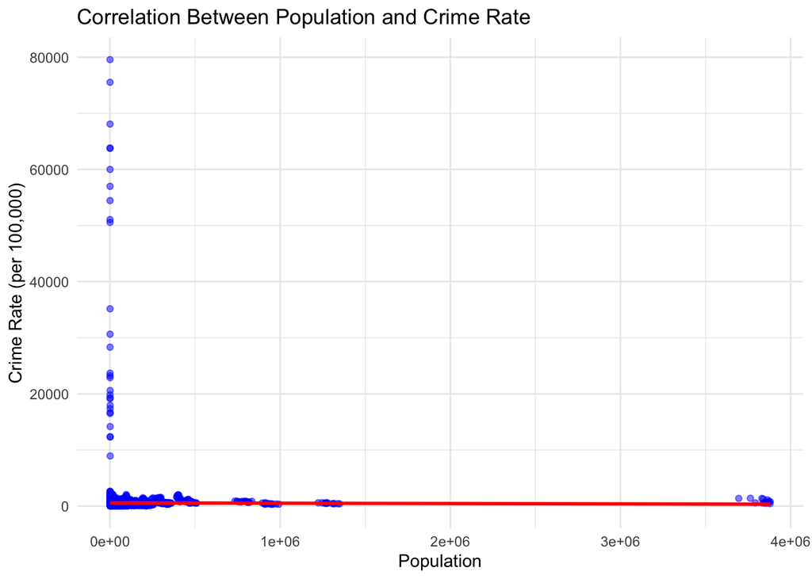

```r
ggplot(cleaned_crimes, aes(x = population, y = crime_rate)) +
  geom_point(alpha = 0.5, color = "blue") +
  geom_smooth(method = "lm", color = "red", se = FALSE) +
  labs(
    title = "Correlation Between Population and Crime Rate",
    x = "Population",
    y = "Crime Rate (per 100,000)"
  ) +
  theme_minimal()
```

## Visualization & Interpretation

#### 1. Scatter Plot with Linear Regression Trendline

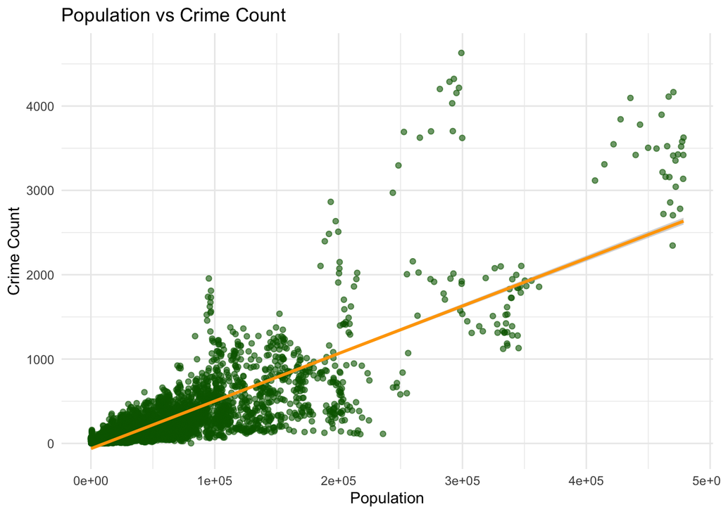

```r
ggplot(cleaned_crimes %>% filter(population <= quantile(population, 0.99),
                                 crime_count <= quantile(crime_count, 0.99)),
       aes(x = population, y = crime_count)) +
  geom_point(alpha = 0.6, color = "darkgreen") +
  geom_smooth(method = "lm", se = TRUE, color = "orange") +
  labs(
    title = "Population vs Crime Count",
    x = "Population",
    y = "Crime Count"
  ) +
  theme_minimal()
```

##### Interpretation:

- There is a positive correlation between population and the number of crimes, indicating that more populous areas tend to report more crimes.
- The orange regression line shows the overall trend, suggesting that crime count increases linearly with population size.
- Outliers with high population but relatively lower crime counts suggest possible variations in law enforcement or unreported crimes.

#### 2. Time Series Chart for Crime Rates by Region

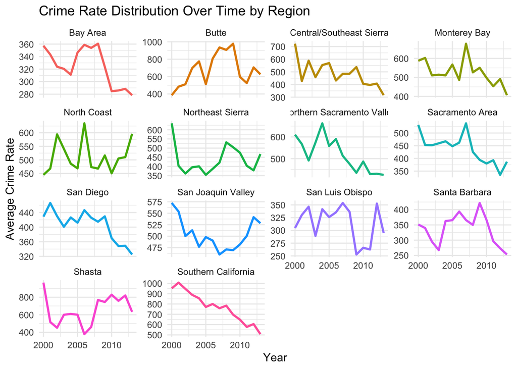

```r
ggplot(cleaned_crimes, aes(x = year, y = crime_rate, color = region_name)) +
  geom_line(stat = "summary", fun = "mean", size = 1) +
  facet_wrap(~ region_name, scales = "free_y") +
  labs(
    title = "Crime Rate Distribution Over Time by Region",
    x = "Year",
    y = "Average Crime Rate"
  ) +
  theme_minimal() +
  theme(legend.position = "none")
```

#### Interpretation:

- Crime rates vary significantly across regions, with certain regions consistently showing higher averages over the years.
- Some regions exhibit a decreasing trend in crime rates, indicating potential improvements in public safety measures.
- Peaks in crime rates during specific years may correspond to societal or economic factors affecting the respective regions.

#### 3. Crime Count By County - Bar Chart

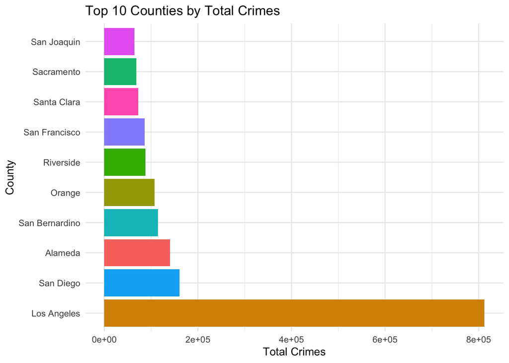

```r
top_counties <- cleaned_crimes %>%
  group_by(county_name) %>%
  summarise(total_crimes = sum(crime_count)) %>%
  top_n(10, total_crimes)

ggplot(top_counties, aes(x = reorder(county_name, -total_crimes), y = total_crimes, fill = county_name)) +
  geom_bar(stat = "identity") +
  labs(
    title = "Top 10 Counties by Total Crimes",
    x = "County",
    y = "Total Crimes"
  ) +
  theme_minimal() +
  theme(legend.position = "none") +
  coord_flip()
```

#### Interpretation:

- The top 10 counties contribute disproportionately to the total number of crimes, suggesting regional hotspots for criminal activity.
- Counties with higher crime counts may require targeted interventions to address local factors driving crime.
- Variations in crime counts among the top counties highlight regional disparities in crime incidence.

#### 4. Crime Rate Heatmap

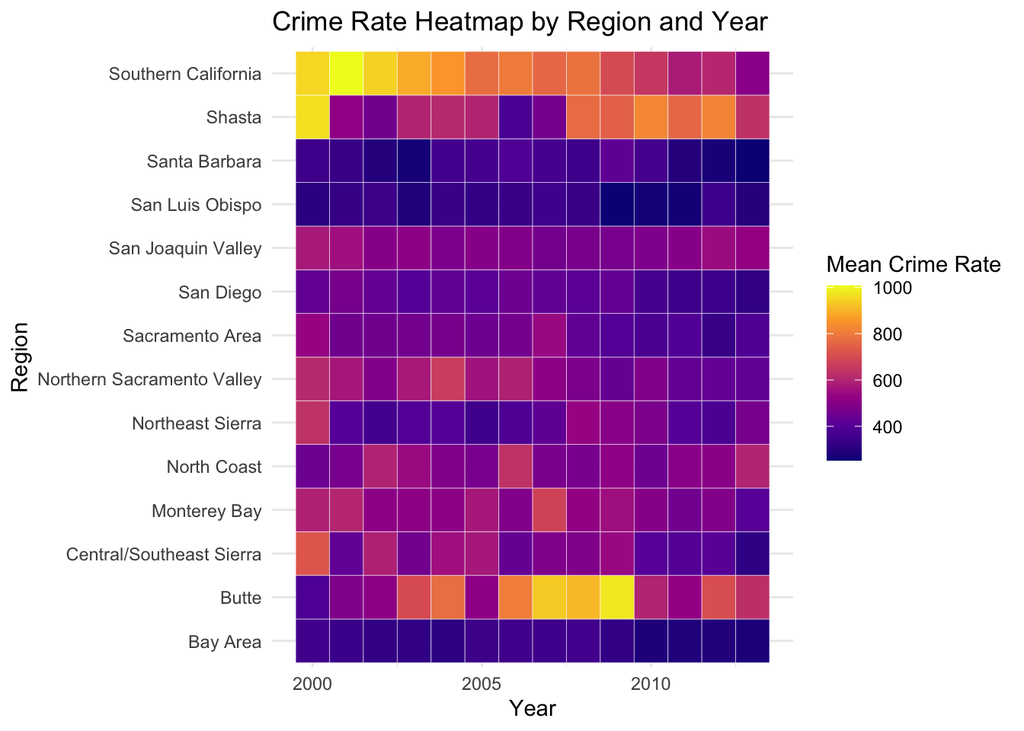

```r
regional_crime_heatmap <- cleaned_crimes %>%
  group_by(year, region_name) %>%
  summarise(mean_crime_rate = mean(crime_rate))
ggplot(regional_crime_heatmap, aes(x = year, y = region_name, fill = mean_crime_rate)) +
  geom_tile(color = "white") +
  scale_fill_viridis_c(option = "plasma", name = "Mean Crime Rate") +
  labs(
    title = "Crime Rate Heatmap by Region and Year",
    x = "Year",
    y = "Region"
  ) +
  theme_minimal()
```

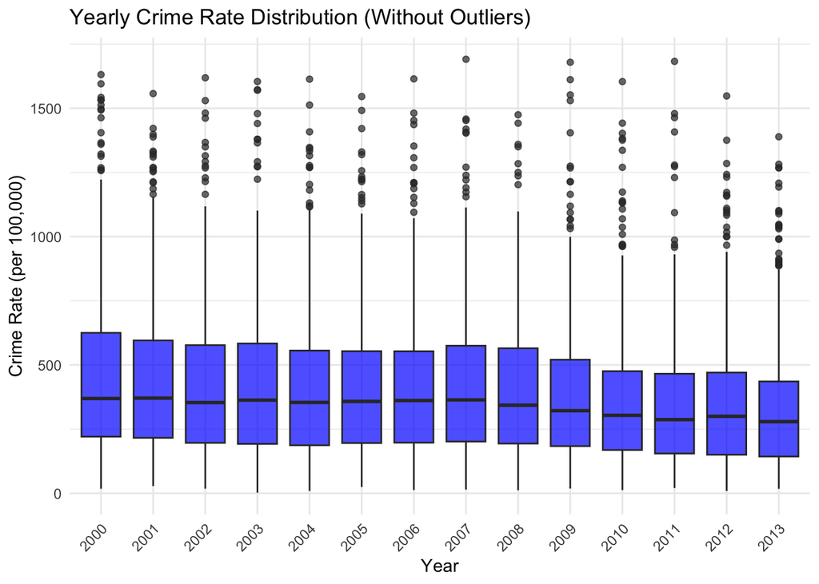

```r
ggplot(cleaned_crimes %>% filter(crime_rate <= quantile(crime_rate, 0.99)),
       aes(x = factor(year), y = crime_rate)) +
  geom_boxplot(fill = "blue", alpha = 0.7) +
  labs(
    title = "Yearly Crime Rate Distribution (Without Outliers)",
    x = "Year",
    y = "Crime Rate (per 100,000)"
  ) +
  theme_minimal() +
  theme(axis.text.x = element_text(angle = 45, hjust = 1))
```

#### Interpretation:

- Median crime rates have remained relatively stable over the years, as indicated by the consistent interquartile range.
- The presence of outliers suggests occasional surges in crime rates in certain areas or years.
- A reduction in the range of crime rates in recent years may indicate improved consistency in law enforcement efforts.

#### 6. Density Plot

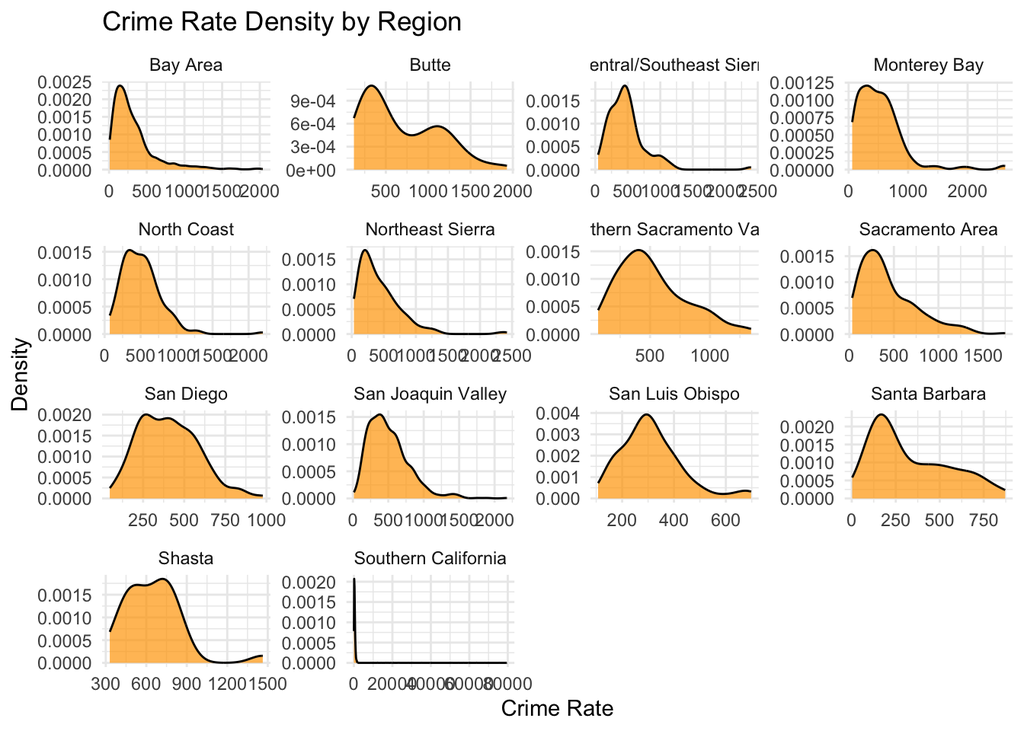

```r
ggplot(cleaned_crimes, aes(x = crime_rate)) +
  geom_density(fill = "orange", alpha = 0.7) +
  facet_wrap(~ region_name, scales = "free") +
  labs(
    title = "Crime Rate Density by Region",
    x = "Crime Rate",
    y = "Density"
  ) +
  theme_minimal()
```

#### Interpretation:

- Crime rate distributions vary widely across regions, with some regions showing a higher concentration of low crime rates.
- Regions with multiple density peaks indicate diverse sub-regions with differing crime dynamics.
- Overlapping densities suggest shared trends in crime rates among geographically or demographically similar regions.

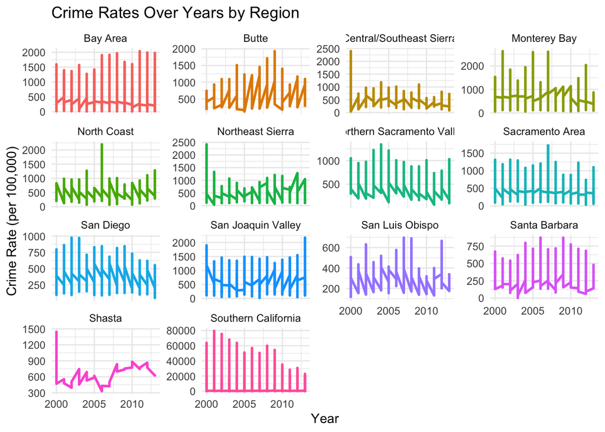

```r
ggplot(cleaned_crimes, aes(x = year, y = crime_rate, group = region_name, color = region_name)) +
  geom_line(size = 1) +
  facet_wrap(~ region_name, scales = "free_y") +
  labs(
    title = "Crime Rates Over Years by Region",
    x = "Year",
    y = "Crime Rate (per 100,000)"
  ) +
  theme_minimal() +
  theme(legend.position = "none")
```

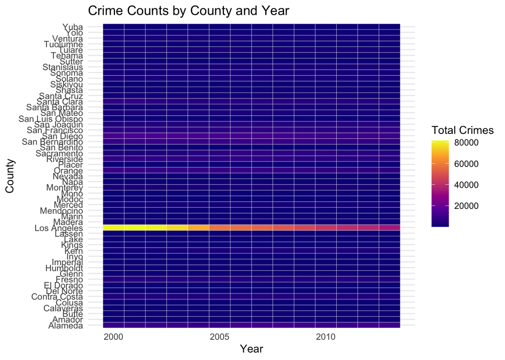

```r
crime_heatmap_data <- cleaned_crimes %>%
  group_by(year, county_name) %>%
  summarise(total_crimes = sum(crime_count)) %>%
  ungroup()
ggplot(crime_heatmap_data, aes(x = year, y = county_name, fill = total_crimes)) +
  geom_tile(color = "white") +
  scale_fill_viridis_c(option = "plasma", name = "Total Crimes") +
  labs(
    title = "Crime Counts by County and Year",
    x = "Year",
    y = "County"
  ) +
  theme_minimal()
```

#### 9. Crime Types Pie Chart

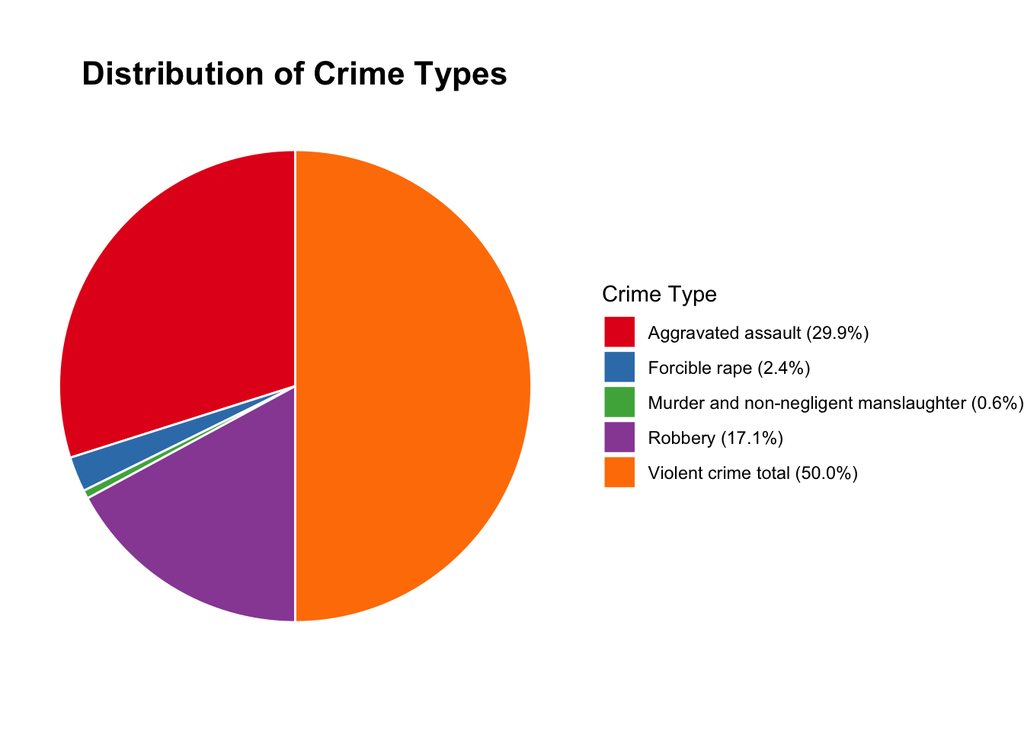

```r
# Aggregate data by crime type, including "Violent crime total"
crime_type_totals <- crimes_data %>%
  group_by(strata_level_name) %>%
  summarise(
    total_incidents = sum(numerator, na.rm = TRUE)
  ) %>%
  filter(total_incidents > 0) # Ensure valid totals

# Calculate percentages and update legend labels
crime_type_totals <- crime_type_totals %>%
  mutate(
    percentage = total_incidents / sum(total_incidents) * 100,
    legend_label = sprintf("%s (%.1f%%)", strata_level_name, percentage), # Attach percentage to name
    label = sprintf("%.1f%%", percentage) # Only display percentage in the pie chart
  )

# Create the improved pie chart
ggplot(crime_type_totals, aes(x = "", y = total_incidents, fill = legend_label)) +
  geom_bar(stat = "identity", width = 1, color = "white") + # Add white border for better slice separation
  coord_polar("y", start = 0) +
  scale_fill_brewer(palette = "Set1") + # Use a visually distinct palette
  labs(
    title = "Distribution of Crime Types",
    x = NULL,
    y = NULL,
    fill = "Crime Type" # Updated legend with percentages
  ) +
  theme_void() + # Remove unnecessary chart elements
  theme(
    legend.position = "right",
    plot.title = element_text(size = 16, face = "bold", hjust = 0.5) # Center and bold title
  )
```

#### 10. Bar Chart Representing Top Counties with Highest Crime Rates

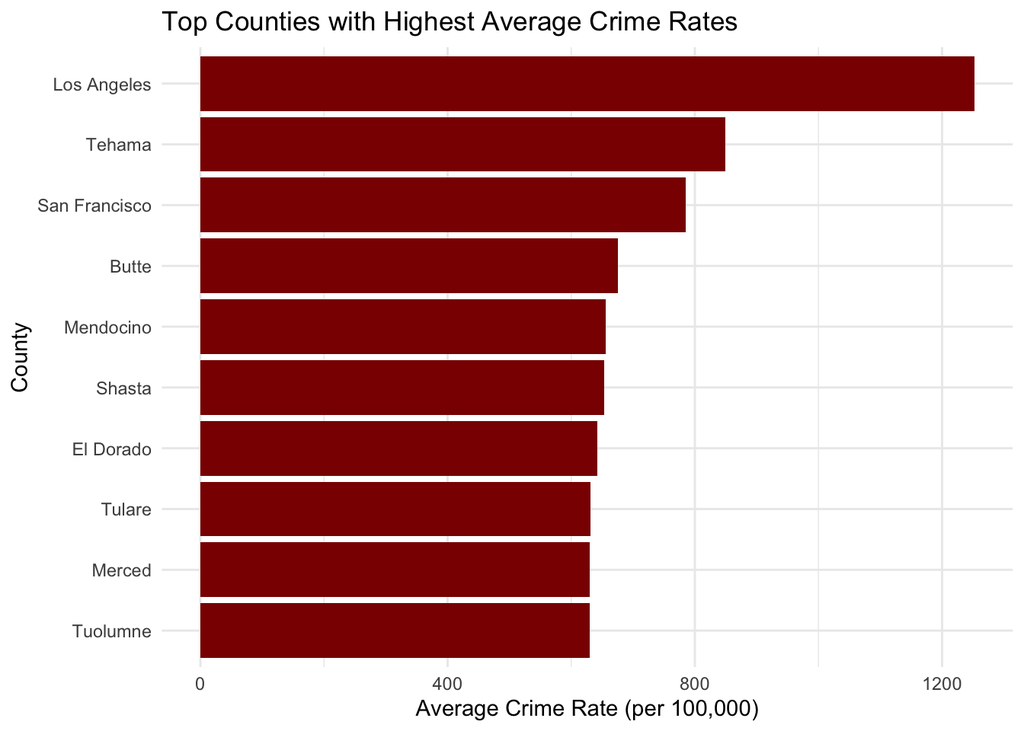

```r
top_counties <- cleaned_crimes %>%
  group_by(county_name) %>%
  summarise(avg_crime_rate = mean(crime_rate)) %>%
  top_n(10, avg_crime_rate) %>%
  arrange(desc(avg_crime_rate))

ggplot(top_counties, aes(x = reorder(county_name, avg_crime_rate), y = avg_crime_rate)) +
  geom_bar(stat = "identity", fill = "#8B0000") +
  labs(
    title = "Top Counties with Highest Average Crime Rates",
    x = "County",
    y = "Average Crime Rate (per 100,000)"
  ) +
  theme_minimal() +
  coord_flip()
```

#### Interpretation:

- The top counties with the highest average crime rates may require enhanced resources or policy changes to address persistent issues.
- Disparities among counties indicate the unequal distribution of crime challenges across the state.
- This chart provides a clear indication of areas where preventive measures could significantly impact overall crime rates.

#### 11. Crime Count Over Time by Crime Type

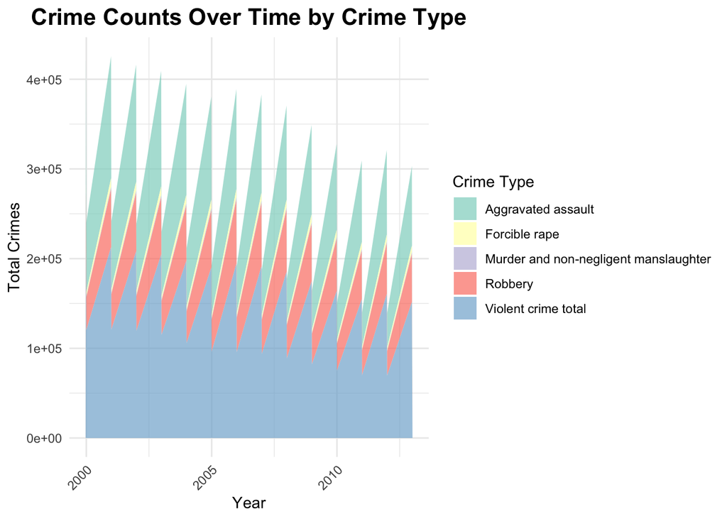

```r
# Ensure necessary columns are present and rename for clarity
cleaned_crimes2 <- crimes_data %>%
  rename(
    year = reportyear,
    crime_type = strata_level_name,
    crime_count = numerator
  ) %>%
  filter(
    !is.na(year), # Remove rows with missing years
    !is.na(crime_count), # Remove rows with missing crime counts
    !is.na(crime_type) # Remove rows with missing crime types
  ) %>%
  mutate(
    year = as.integer(year), # Ensure year is an integer for plotting
    crime_count = as.numeric(crime_count) # Ensure crime_count is numeric
  )

# Create the area plot
ggplot(cleaned_crimes2, aes(x = year, y = crime_count, fill = crime_type)) +
  geom_area(alpha = 0.7, position = "stack") + # Stacked area chart
  scale_fill_brewer(palette = "Set3") + # Use a clear, professional color palette
  labs(
    title = "Crime Counts Over Time by Crime Type",
    x = "Year",
    y = "Total Crimes",
    fill = "Crime Type"
  ) +
  theme_minimal() + # Use a minimal theme for clean visualization
  theme(
    legend.position = "right",
    plot.title = element_text(size = 16, face = "bold", hjust = 0.5), # Center and bold title
    axis.text.x = element_text(angle = 45, hjust = 1) # Rotate x-axis labels for better readability
  )
```

## Conclusion

- The analysis highlights distinct crime trends across regions, counties, and crime types, providing actionable insights for targeted interventions.
- Consistently high crime rates in specific regions emphasize the need for localized crime prevention strategies.
- Variations in crime rates over time suggest that societal, economic, and policy factors significantly influence crime dynamics.
- The visualization of crime types illustrates dominant categories, underscoring areas - requiring focused attention and resources.
- The correlation between population and crime count confirms the need for proportionate law enforcement measures in populous areas.
- Overall, the study provides a comprehensive understanding of crime patterns in California, aiding policymakers and law enforcement in effective decision-making.